# r4ds Chapter 5 - Transforming Tidy Data

Gabriel J. Odom, PhD, ThD

gabriel.odom@med.miami.edu

March 19, 2018

# 1 Introduction

These notes are designed to act as a gentle introduction to some data transformation and manipulation possibilities using the suite of `R` packages known as the `tidyverse`. We assume the user already has some very basic understanding of executing `R` code and using the [RStudio](https://www.rstudio.com/) integrated development environment (IDE). The examples and layout of this chapter are drawn directly from chapter five of Grolemund and Wickham’s text, [R for Data Science](http://r4ds.had.co.nz/index.html). We strongly recommend this book.

## 1.1 The `tidyverse` Suite

We first load the `tidyverse` package suite.

```r
library(tidyverse)
```

This suite contains the following packages:

- `dplyr`: a “pair of pliers” for tidy `data.frame` objects
- `forcats`: a set of tools “for cat-” egorical variables, i.e. `factor` variables
- `ggplot2`: plotting with the “layered **G**rammar of **G**raphics”
- `purrr`: a functional programming toolkit to make your functions “purr” over lists
- `readr`: read data into `R`
- `stringr`: do things with strings
- `tibble`: create the `table + data.frame` joint class, or `tbl_df` (pronounced “tibble”)
- `tidyr`: “tidy-up” your raw data

We are discussing transforming and manipulating *tidy* data frames today, so we will take a closer look at the `dplyr` package.

## 1.2 Review

We saw the power of the `ggplot2` packge in action in our January seminar. In the February seminar, we discussed the object-oriented basics of `R` code, how to organise and document your code in scripts, and how to organise your scripts into a project. Here are some cheat sheets and other helpful links to jog your memory:

- [`R` Basics](https://www.rstudio.com/wp-content/uploads/2016/05/base-r.pdf)
- [Graphics with `ggplot2`](https://www.rstudio.com/wp-content/uploads/2015/03/ggplot2-cheatsheet.pdf)
- [Data Wrangling with `dplyr`](https://www.rstudio.com/wp-content/uploads/2015/02/data-wrangling-cheatsheet.pdf) (our topic for today)
- [Importing Data with `readr`](https://ugoproto.github.io/ugo_r_doc/data-import.pdf) (helpful for our next session)
- [Tidying Imported Data with `tidyr`](https://cran.r-project.org/web/packages/tidyr/vignettes/tidy-data.html) (also helpful for our next session)

## 1.3 Example Data: Flights Departing New York City in 2013

Our data set is a table data frame (or `tibble`) of measurements on all flights departing the Greater New York City area in 2013. It has 336,776 unique flights and 19 measurements on those flights. We will use this data set to explore a few of the more commonly-used `dplyr` functions.

```r
install.packages("nycflights13")
```

```r
library(nycflights13)
flights
```

```
## # A tibble: 336,776 x 19
##     year month   day dep_time sched_dep_time dep_delay arr_time
##    <int> <int> <int>    <int>          <int>     <dbl>    <int>
##  1  2013     1     1      517            515         2      830
##  2  2013     1     1      533            529         4      850
##  3  2013     1     1      542            540         2      923
##  4  2013     1     1      544            545        -1     1004
##  5  2013     1     1      554            600        -6      812
##  6  2013     1     1      554            558        -4      740
##  7  2013     1     1      555            600        -5      913
##  8  2013     1     1      557            600        -3      709
##  9  2013     1     1      557            600        -3      838
## 10  2013     1     1      558            600        -2      753
## # ... with 336,766 more rows, and 12 more variables: sched_arr_time <int>,
## #   arr_delay <dbl>, carrier <chr>, flight <int>, tailnum <chr>,
## #   origin <chr>, dest <chr>, air_time <dbl>, distance <dbl>, hour <dbl>,
## #   minute <dbl>, time_hour <dttm>
```

## 1.4 Overview of Common Functions

These functions all operate on tidy data frames:

- `filter()`: return rows that match a certain set of conditions
- `arrange()`: sort rows by a given set of measurements
- `select()`: select, rename, and / or reorder columns
- `mutate()`: create new columns (often as functions of your existing columns)
- `group_by()`: group rows by chosen columns
- `summarise()`: collapse multiple rows into one (often paired with `group_by()` for group summaries)

All of these functions have very similar syntax: `function(data_df, ...)`. The ellipsis will take in the additional conditions or arguments for the function, and column names are passed unquoted. Additionally, these functions **do not** create new data objects. If you want to keep the transformed data table you’ve created, you **must** store it as an object.

# 2 Subset Rows with `filter()`

The filter function takes in the data frame and a logical argument. Rows that return `TRUE` for that logical argument are returned as a subset of the original data frame. For example, we would like to inspect only flights that happened on 1 January, 2013.

```r
filter(flights, month == 1, day == 1)
```

```
## # A tibble: 842 x 19
##     year month   day dep_time sched_dep_time dep_delay arr_time
##    <int> <int> <int>    <int>          <int>     <dbl>    <int>
##  1  2013     1     1      517            515         2      830
##  2  2013     1     1      533            529         4      850
##  3  2013     1     1      542            540         2      923
##  4  2013     1     1      544            545        -1     1004
##  5  2013     1     1      554            600        -6      812
##  6  2013     1     1      554            558        -4      740
##  7  2013     1     1      555            600        -5      913
##  8  2013     1     1      557            600        -3      709
##  9  2013     1     1      557            600        -3      838
## 10  2013     1     1      558            600        -2      753
## # ... with 832 more rows, and 12 more variables: sched_arr_time <int>,
## #   arr_delay <dbl>, carrier <chr>, flight <int>, tailnum <chr>,
## #   origin <chr>, dest <chr>, air_time <dbl>, distance <dbl>, hour <dbl>,
## #   minute <dbl>, time_hour <dttm>
```

This code selects the 842 rows of the `flights` data frame where the `month` column is equal to the number 1 (for January) and the `day` column is also equal to 1.

## 2.1 R Basics Refresher

### 2.1.1 Side Note: Comparing Values

In order to check if the values in the `month` column were equal to the number 1, we needed a comparison function for the equality of two objects. In `R`, we have the following simple comparison tools for integers and real numbers:

```r
A <- 2
B <- 3
A > B  # A greater than B?
```

```
## [1] FALSE
```

```r
A >= B # A greater than or equal to B?
```

```
## [1] FALSE
```

```r
A < B  # A less than B?
```

```
## [1] TRUE
```

```r
A <= B # A less than or equal to B?
```

```
## [1] TRUE
```

```r
A == B # A equal to B?
```

```
## [1] FALSE
```

```r
A != B # A not equal to B?
```

```
## [1] TRUE
```

Notice that comparing equality requires two equal signs, not one.

### 2.1.2 Side Note: Missing Values in `R`

Missing values in `R` are represented by `NA`: not `-999`, `?`, `" "`, or even `NaN`. When you import any data into `R`, pay attention to the missing value codes from other data analysis software. `R` treats missing values (the `NA`s) as a statement saying “I don’t know”. Also, understand that missing values are “contagious” in `R`. Here are some examples:

```r
NA < 3    # Is something I don't know less than 3? I don't know.
```

```
## [1] NA
```

```r
NA * 2    # What is "I don't know" multiplied by 2? I don't know.
```

```
## [1] NA
```

```r
NA & TRUE # Are these both TRUE? I don't know.
```

```
## [1] NA
```

```r
NA | TRUE # Are either of these TRUE? Yes, one of them is TRUE.
```

```
## [1] TRUE
```

```r
NA == NA  # Is something I don't know equal to something else I don't know? I don't know.
```

```
## [1] NA
```

```r
is.na(NA) # Is this something we don't know? Yes.
```

```
## [1] TRUE
```

### 2.1.3 Side Note: Logical Operators

There are three logical operators we will commonly employ: AND, OR, and NOT.

```r
x <- TRUE
y <- FALSE
x | y # Are either x or y TRUE?
```

```
## [1] TRUE
```

```r
x & y # Are both x and y TRUE?
```

```
## [1] FALSE
```

```r
!x    # What is the opposite of x?
```

```
## [1] FALSE
```

There are two more operators to think about, but they are shorthands for the primary three.

```r
# The XOR operator:
(x | y) & !(x & y) # are x or y TRUE, but not both?
```

```
## [1] TRUE
```

```r
xor(x, y)
```

```
## [1] TRUE
```

```r
# The Set Membership operator
A == 1 | A == 2 | A == 3
```

```
## [1] TRUE
```

```r
A %in% c(1, 2, 3)
```

```
## [1] TRUE
```

## 2.2 Examples

1. Find all the flights on Christmas Eve. We’ll use the *pipe operator* from last session, but the code is exactly the same as the code for finding all the New Year’s Day flights.

```r
flights %>% filter(month == 12, day == 24)
```

```
## # A tibble: 761 x 19
##     year month   day dep_time sched_dep_time dep_delay arr_time
##    <int> <int> <int>    <int>          <int>     <dbl>    <int>
##  1  2013    12    24        9           2359        10      444
##  2  2013    12    24      458            500        -2      652
##  3  2013    12    24      513            515        -2      813
##  4  2013    12    24      543            540         3      844
##  5  2013    12    24      546            550        -4     1032
##  6  2013    12    24      555            600        -5      851
##  7  2013    12    24      556            600        -4      845
##  8  2013    12    24      557            600        -3      908
##  9  2013    12    24      558            600        -2      827
## 10  2013    12    24      558            600        -2      729
## # ... with 751 more rows, and 12 more variables: sched_arr_time <int>,
## #   arr_delay <dbl>, carrier <chr>, flight <int>, tailnum <chr>,
## #   origin <chr>, dest <chr>, air_time <dbl>, distance <dbl>, hour <dbl>,
## #   minute <dbl>, time_hour <dttm>
```

As a review, the pipe turns `x %>% f(y)` into `f(x, y)`. Pipes allow us to read code from left-to-right and top-to-bottom, rather than inside out with a giant nest of parentheses.

2. Find all flights during the summer months (June, July, and August).

```r
filter(flights, month %in% c(6, 7, 8))
```

```
## # A tibble: 86,995 x 19
##     year month   day dep_time sched_dep_time dep_delay arr_time
##    <int> <int> <int>    <int>          <int>     <dbl>    <int>
##  1  2013     6     1        2           2359         3      341
##  2  2013     6     1      451            500        -9      624
##  3  2013     6     1      506            515        -9      715
##  4  2013     6     1      534            545       -11      800
##  5  2013     6     1      538            545        -7      925
##  6  2013     6     1      539            540        -1      832
##  7  2013     6     1      546            600       -14      850
##  8  2013     6     1      551            600        -9      828
##  9  2013     6     1      552            600        -8      647
## 10  2013     6     1      553            600        -7      700
## # ... with 86,985 more rows, and 12 more variables: sched_arr_time <int>,
## #   arr_delay <dbl>, carrier <chr>, flight <int>, tailnum <chr>,
## #   origin <chr>, dest <chr>, air_time <dbl>, distance <dbl>, hour <dbl>,
## #   minute <dbl>, time_hour <dttm>
```

3. Find all flights that did *not* depart from Newark Liberty.

```r
filter(flights, origin != "EWR")
```

```
## # A tibble: 215,941 x 19
##     year month   day dep_time sched_dep_time dep_delay arr_time
##    <int> <int> <int>    <int>          <int>     <dbl>    <int>
##  1  2013     1     1      533            529         4      850
##  2  2013     1     1      542            540         2      923
##  3  2013     1     1      544            545        -1     1004
##  4  2013     1     1      554            600        -6      812
##  5  2013     1     1      557            600        -3      709
##  6  2013     1     1      557            600        -3      838
##  7  2013     1     1      558            600        -2      753
##  8  2013     1     1      558            600        -2      849
##  9  2013     1     1      558            600        -2      853
## 10  2013     1     1      558            600        -2      924
## # ... with 215,931 more rows, and 12 more variables: sched_arr_time <int>,
## #   arr_delay <dbl>, carrier <chr>, flight <int>, tailnum <chr>,
## #   origin <chr>, dest <chr>, air_time <dbl>, distance <dbl>, hour <dbl>,
## #   minute <dbl>, time_hour <dttm>
```

4. Find all JetBlue (“B6”) or Southwest (“WN”) flights.

```r
filter(flights, carrier == "B6" | carrier == "WN")
```

```
## # A tibble: 66,910 x 19
##     year month   day dep_time sched_dep_time dep_delay arr_time
##    <int> <int> <int>    <int>          <int>     <dbl>    <int>
##  1  2013     1     1      544            545        -1     1004
##  2  2013     1     1      555            600        -5      913
##  3  2013     1     1      557            600        -3      838
##  4  2013     1     1      558            600        -2      849
##  5  2013     1     1      558            600        -2      853
##  6  2013     1     1      559            559         0      702
##  7  2013     1     1      600            600         0      851
##  8  2013     1     1      601            600         1      844
##  9  2013     1     1      613            610         3      925
## 10  2013     1     1      615            615         0     1039
## # ... with 66,900 more rows, and 12 more variables: sched_arr_time <int>,
## #   arr_delay <dbl>, carrier <chr>, flight <int>, tailnum <chr>,
## #   origin <chr>, dest <chr>, air_time <dbl>, distance <dbl>, hour <dbl>,
## #   minute <dbl>, time_hour <dttm>
```

5. Find any flights out of LaGuardia that actually left on time.

```r
filter(flights, origin == "LGA" & dep_delay <= 0)
```

```
## # A tibble: 67,819 x 19
##     year month   day dep_time sched_dep_time dep_delay arr_time
##    <int> <int> <int>    <int>          <int>     <dbl>    <int>
##  1  2013     1     1      554            600        -6      812
##  2  2013     1     1      557            600        -3      709
##  3  2013     1     1      558            600        -2      753
##  4  2013     1     1      559            600        -1      941
##  5  2013     1     1      600            600         0      851
##  6  2013     1     1      600            600         0      837
##  7  2013     1     1      602            610        -8      812
##  8  2013     1     1      602            605        -3      821
##  9  2013     1     1      623            627        -4      933
## 10  2013     1     1      624            630        -6      840
## # ... with 67,809 more rows, and 12 more variables: sched_arr_time <int>,
## #   arr_delay <dbl>, carrier <chr>, flight <int>, tailnum <chr>,
## #   origin <chr>, dest <chr>, air_time <dbl>, distance <dbl>, hour <dbl>,
## #   minute <dbl>, time_hour <dttm>
```

# 3 Sort Rows with `arrange()`

The `arrange()` function takes in a data frame and a set of columns to sort on. We can sort the flights by in increasing order by the day of the year: we sort by month, then by day within month.

```r
arrange(flights, year, month, day)
```

```
## # A tibble: 336,776 x 19
##     year month   day dep_time sched_dep_time dep_delay arr_time
##    <int> <int> <int>    <int>          <int>     <dbl>    <int>
##  1  2013     1     1      517            515         2      830
##  2  2013     1     1      533            529         4      850
##  3  2013     1     1      542            540         2      923
##  4  2013     1     1      544            545        -1     1004
##  5  2013     1     1      554            600        -6      812
##  6  2013     1     1      554            558        -4      740
##  7  2013     1     1      555            600        -5      913
##  8  2013     1     1      557            600        -3      709
##  9  2013     1     1      557            600        -3      838
## 10  2013     1     1      558            600        -2      753
## # ... with 336,766 more rows, and 12 more variables: sched_arr_time <int>,
## #   arr_delay <dbl>, carrier <chr>, flight <int>, tailnum <chr>,
## #   origin <chr>, dest <chr>, air_time <dbl>, distance <dbl>, hour <dbl>,
## #   minute <dbl>, time_hour <dttm>
```

Also, we can sort the flights by departure delay time.

```r
arrange(flights, desc(dep_delay))
```

```
## # A tibble: 336,776 x 19
##     year month   day dep_time sched_dep_time dep_delay arr_time
##    <int> <int> <int>    <int>          <int>     <dbl>    <int>
##  1  2013     1     9      641            900      1301     1242
##  2  2013     6    15     1432           1935      1137     1607
##  3  2013     1    10     1121           1635      1126     1239
##  4  2013     9    20     1139           1845      1014     1457
##  5  2013     7    22      845           1600      1005     1044
##  6  2013     4    10     1100           1900       960     1342
##  7  2013     3    17     2321            810       911      135
##  8  2013     6    27      959           1900       899     1236
##  9  2013     7    22     2257            759       898      121
## 10  2013    12     5      756           1700       896     1058
## # ... with 336,766 more rows, and 12 more variables: sched_arr_time <int>,
## #   arr_delay <dbl>, carrier <chr>, flight <int>, tailnum <chr>,
## #   origin <chr>, dest <chr>, air_time <dbl>, distance <dbl>, hour <dbl>,
## #   minute <dbl>, time_hour <dttm>
```

Further, we can combine this with the `filter()` commmand to sort the American Airlines flights out of JFK on the day before Thanksgiving by their duration. By the way, see how easy it is to chain rather complicated commands together? You might begin to imagine that we are only scratching the surface of what we can do with `dplyr`…

```r
flights %>%
  filter(carrier == "AA") %>%
  filter(origin == "JFK") %>%
  filter(month == 11) %>%
  filter(day == 27) %>%
  arrange(desc(air_time))
```

```
## # A tibble: 37 x 19
##     year month   day dep_time sched_dep_time dep_delay arr_time
##    <int> <int> <int>    <int>          <int>     <dbl>    <int>
##  1  2013    11    27     1529           1530        -1     1903
##  2  2013    11    27      805            800         5     1129
##  3  2013    11    27     1740           1745        -5     2103
##  4  2013    11    27     1022           1030        -8     1319
##  5  2013    11    27      724            730        -6     1058
##  6  2013    11    27     1340           1345        -5     1648
##  7  2013    11    27     1543           1545        -2     1845
##  8  2013    11    27     1849           1850        -1     2209
##  9  2013    11    27     1900           1900         0     2229
## 10  2013    11    27     1141            900       161     1429
## # ... with 27 more rows, and 12 more variables: sched_arr_time <int>,
## #   arr_delay <dbl>, carrier <chr>, flight <int>, tailnum <chr>,
## #   origin <chr>, dest <chr>, air_time <dbl>, distance <dbl>, hour <dbl>,
## #   minute <dbl>, time_hour <dttm>
```

As an aside, look how clean this code looks because of our pipes! Imagine trying to write this as a set of nested functions. Not pretty.

# 4 Select and Move Columns with `select()`

While `filter()` and `arrange()` help us select and sort individual observations (rows), the `select()` function helps us select, rename, or reorder the measurements (columns) of a data frame.

## 4.1 Select Columns that Meet Our Criteria

We first select three columns specifically by their names.

```r
select(flights, year, month, day)
```

```
## # A tibble: 336,776 x 3
##     year month   day
##    <int> <int> <int>
##  1  2013     1     1
##  2  2013     1     1
##  3  2013     1     1
##  4  2013     1     1
##  5  2013     1     1
##  6  2013     1     1
##  7  2013     1     1
##  8  2013     1     1
##  9  2013     1     1
## 10  2013     1     1
## # ... with 336,766 more rows
```

Notice that we only have the three columns we explicitly requested by name *and no more*. The `select()` function will drop whatever we don’t ask for by default, but we can change this behaviour by adding the additional `everything()` argument (we’ll come back to this in the “reordering columns” section).

We could have also specified a range of column names to achieve the same effect.

```r
select(flights, year:day)
```

```
## # A tibble: 336,776 x 3
##     year month   day
##    <int> <int> <int>
##  1  2013     1     1
##  2  2013     1     1
##  3  2013     1     1
##  4  2013     1     1
##  5  2013     1     1
##  6  2013     1     1
##  7  2013     1     1
##  8  2013     1     1
##  9  2013     1     1
## 10  2013     1     1
## # ... with 336,766 more rows
```

If you have used regular expressions or performed string manipulation before, you can also use the following modifiers to the `select()` function:

1. Find all the columns with names starting with “dep_”.

```r
select(flights, starts_with("dep_"))
```

```
## # A tibble: 336,776 x 2
##    dep_time dep_delay
##       <int>     <dbl>
##  1      517         2
##  2      533         4
##  3      542         2
##  4      544        -1
##  5      554        -6
##  6      554        -4
##  7      555        -5
##  8      557        -3
##  9      557        -3
## 10      558        -2
## # ... with 336,766 more rows
```

2. Find all the columns with names ending with “ay”.

```r
select(flights, ends_with("ay"))
```

```
## # A tibble: 336,776 x 3
##      day dep_delay arr_delay
##    <int>     <dbl>     <dbl>
##  1     1         2        11
##  2     1         4        20
##  3     1         2        33
##  4     1        -1       -18
##  5     1        -6       -25
##  6     1        -4        12
##  7     1        -5        19
##  8     1        -3       -14
##  9     1        -3        -8
## 10     1        -2         8
## # ... with 336,766 more rows
```

3. Find all the columns with names that contain “time”.

```r
select(flights, contains("time"))
```

```
## # A tibble: 336,776 x 6
##    dep_time sched_dep_time arr_time sched_arr_time air_time
##       <int>          <int>    <int>          <int>    <dbl>
##  1      517            515      830            819      227
##  2      533            529      850            830      227
##  3      542            540      923            850      160
##  4      544            545     1004           1022      183
##  5      554            600      812            837      116
##  6      554            558      740            728      150
##  7      555            600      913            854      158
##  8      557            600      709            723       53
##  9      557            600      838            846      140
## 10      558            600      753            745      138
## # ... with 336,766 more rows, and 1 more variable: time_hour <dttm>
```

4. Find all the columns with names that start with exactly three lower case letters followed by “_“.

```r
select(flights, matches("^[a-z]{3}\\_"))
```

```
## # A tibble: 336,776 x 5
##    dep_time dep_delay arr_time arr_delay air_time
##       <int>     <dbl>    <int>     <dbl>    <dbl>
##  1      517         2      830        11      227
##  2      533         4      850        20      227
##  3      542         2      923        33      160
##  4      544        -1     1004       -18      183
##  5      554        -6      812       -25      116
##  6      554        -4      740        12      150
##  7      555        -5      913        19      158
##  8      557        -3      709       -14       53
##  9      557        -3      838        -8      140
## 10      558        -2      753         8      138
## # ... with 336,766 more rows
```

The `matches()` function takes in a *regular expression*. If you have never used regular expressions for string queries before, don’t be afraid. You can do most of the things you need without ever touching the `matches()` function. However, if you do find yourself needing some help with string manipulation in `R`, please see the `stringr` package cheat sheet from the [RStudio Cheat Sheets page](https://www.rstudio.com/resources/cheatsheets/) and [the strings chapter](http://r4ds.had.co.nz/strings.html#strings) from *R for Data Science*.

## 4.2 Remove, Reorder, or Rename

### 4.2.1 Remove Columns

We can also use “negative indexing” to select all the columns *except* for the columns we named.

```r
select(flights, -(year:day))
```

```
## # A tibble: 336,776 x 16
##    dep_time sched_dep_time dep_delay arr_time sched_arr_time arr_delay
##       <int>          <int>     <dbl>    <int>          <int>     <dbl>
##  1      517            515         2      830            819        11
##  2      533            529         4      850            830        20
##  3      542            540         2      923            850        33
##  4      544            545        -1     1004           1022       -18
##  5      554            600        -6      812            837       -25
##  6      554            558        -4      740            728        12
##  7      555            600        -5      913            854        19
##  8      557            600        -3      709            723       -14
##  9      557            600        -3      838            846        -8
## 10      558            600        -2      753            745         8
## # ... with 336,766 more rows, and 10 more variables: carrier <chr>,
## #   flight <int>, tailnum <chr>, origin <chr>, dest <chr>, air_time <dbl>,
## #   distance <dbl>, hour <dbl>, minute <dbl>, time_hour <dttm>
```

This is particularly useful when we have filtered out all of one type of observation. We can then remove the redundant column information. For instance, previously we filtered only the flights leaving on 1 January, 2013. However, we still had the `year`, `month`, and `day` columns in this data table, even though this information was superfluous after filtering.

```r
# Before
flights %>%
  filter(month == 1, day == 1)
```

```
## # A tibble: 842 x 19
##     year month   day dep_time sched_dep_time dep_delay arr_time
##    <int> <int> <int>    <int>          <int>     <dbl>    <int>
##  1  2013     1     1      517            515         2      830
##  2  2013     1     1      533            529         4      850
##  3  2013     1     1      542            540         2      923
##  4  2013     1     1      544            545        -1     1004
##  5  2013     1     1      554            600        -6      812
##  6  2013     1     1      554            558        -4      740
##  7  2013     1     1      555            600        -5      913
##  8  2013     1     1      557            600        -3      709
##  9  2013     1     1      557            600        -3      838
## 10  2013     1     1      558            600        -2      753
## # ... with 832 more rows, and 12 more variables: sched_arr_time <int>,
## #   arr_delay <dbl>, carrier <chr>, flight <int>, tailnum <chr>,
## #   origin <chr>, dest <chr>, air_time <dbl>, distance <dbl>, hour <dbl>,
## #   minute <dbl>, time_hour <dttm>
```

```r
# After
flights %>%
  filter(month == 1, day == 1) %>%
  select(-year, -month, -day)
```

```
## # A tibble: 842 x 16
##    dep_time sched_dep_time dep_delay arr_time sched_arr_time arr_delay
##       <int>          <int>     <dbl>    <int>          <int>     <dbl>
##  1      517            515         2      830            819        11
##  2      533            529         4      850            830        20
##  3      542            540         2      923            850        33
##  4      544            545        -1     1004           1022       -18
##  5      554            600        -6      812            837       -25
##  6      554            558        -4      740            728        12
##  7      555            600        -5      913            854        19
##  8      557            600        -3      709            723       -14
##  9      557            600        -3      838            846        -8
## 10      558            600        -2      753            745         8
## # ... with 832 more rows, and 10 more variables: carrier <chr>,
## #   flight <int>, tailnum <chr>, origin <chr>, dest <chr>, air_time <dbl>,
## #   distance <dbl>, hour <dbl>, minute <dbl>, time_hour <dttm>
```

### 4.2.2 Reorder Columns

As we alluded to above, we can also use the `select()` function to change the order of the columns of the data table, *without removing the columns we don’t explicitely name*, with the helpof the `everything()` function.

```r
select(flights, time_hour, air_time, everything())
```

```
## # A tibble: 336,776 x 19
##    time_hour           air_time  year month   day dep_time sched_dep_time
##    <dttm>                 <dbl> <int> <int> <int>    <int>          <int>
##  1 2013-01-01 05:00:00      227  2013     1     1      517            515
##  2 2013-01-01 05:00:00      227  2013     1     1      533            529
##  3 2013-01-01 05:00:00      160  2013     1     1      542            540
##  4 2013-01-01 05:00:00      183  2013     1     1      544            545
##  5 2013-01-01 06:00:00      116  2013     1     1      554            600
##  6 2013-01-01 05:00:00      150  2013     1     1      554            558
##  7 2013-01-01 06:00:00      158  2013     1     1      555            600
##  8 2013-01-01 06:00:00       53  2013     1     1      557            600
##  9 2013-01-01 06:00:00      140  2013     1     1      557            600
## 10 2013-01-01 06:00:00      138  2013     1     1      558            600
## # ... with 336,766 more rows, and 12 more variables: dep_delay <dbl>,
## #   arr_time <int>, sched_arr_time <int>, arr_delay <dbl>, carrier <chr>,
## #   flight <int>, tailnum <chr>, origin <chr>, dest <chr>, distance <dbl>,
## #   hour <dbl>, minute <dbl>
```

### 4.2.3 Rename Columns

While the `select()` function *can* rename columns, we recommend using the `rename()` function for better readibility of your code instead. This function takes in the data table and an argument that follows the `[new name] = [old name]` syntax. For example, we notice that all of the column names with more than one word are written in `snake_case` except for `tailnum`. We can rename this column to match our naming convention. **However, we *must* save the results of the output of the `rename()` function. Otherwise, the data table with the new column name will print to the screen but never be saved anywhere.** We can use the `names()` function to check that our new name stuck.

```r
flights <- rename(flights, tail_num = tailnum)
names(flights)
```

```
##  [1] "year"           "month"          "day"            "dep_time"
##  [5] "sched_dep_time" "dep_delay"      "arr_time"       "sched_arr_time"
##  [9] "arr_delay"      "carrier"        "flight"         "tail_num"
## [13] "origin"         "dest"           "air_time"       "distance"
## [17] "hour"           "minute"         "time_hour"
```

# 5 Create New Columns with `mutate()`

Up to this point, we have only teased out observational or measurement information that was already in the data table. But what if we want to create a new measurement as a function of some existing measurements? We can do so with the `mutate()` function. This function’s syntax is very similar to the syntax of the `rename()` function: the data frame is first, then `[new column name] = [expression]`.

```r
westCoast <- c("BUR", "HNL", "LAS", "LAX", "OAK", "PDX", "PHX", "PSP", "RNO",
               "SAN", "SEA", "SFO", "SJC", "SLC")
jetStreamFlights <- flights %>%
  filter(dest %in% westCoast) %>%
  select(month, day, dest, ends_with("delay"), distance, air_time)

jetStreamFlights %>%
  mutate(speed_mph = distance / (air_time / 60))
```

```
## # A tibble: 52,377 x 8
##    month   day dest  dep_delay arr_delay distance air_time speed_mph
##    <int> <int> <chr>     <dbl>     <dbl>    <dbl>    <dbl>     <dbl>
##  1     1     1 LAX          -2         7     2475      345      430.
##  2     1     1 SFO          -2       -14     2565      361      426.
##  3     1     1 LAS          -1        -8     2227      337      396.
##  4     1     1 SFO          11        14     2586      366      424.
##  5     1     1 PHX          -8         3     2133      342      374.
##  6     1     1 PHX          -3         0     2153      330      391.
##  7     1     1 LAX          -2        29     2454      366      402.
##  8     1     1 LAS          -4        -6     2248      323      418.
##  9     1     1 SLC           0        -9     1990      294      406.
## 10     1     1 SFO          -5        -8     2586      362      429.
## # ... with 52,367 more rows
```

If we only care about the speeds themselves, we can select the `speed_mph` column we just created.

```r
jetStreamFlights %>%
  mutate(speed_mph = distance / (air_time / 60)) %>%
  select(speed_mph)
```

```
## # A tibble: 52,377 x 1
##    speed_mph
##        <dbl>
##  1      430.
##  2      426.
##  3      396.
##  4      424.
##  5      374.
##  6      391.
##  7      402.
##  8      418.
##  9      406.
## 10      429.
## # ... with 52,367 more rows
```

Alternatively, we could use `mutate()`’s “cousin”, the `transmute()` function. This function is shorthand for `mutate` then `select`.

```r
jetStreamFlights %>%
  transmute(speed_mph = distance / (air_time / 60))
```

```
## # A tibble: 52,377 x 1
##    speed_mph
##        <dbl>
##  1      430.
##  2      426.
##  3      396.
##  4      424.
##  5      374.
##  6      391.
##  7      402.
##  8      418.
##  9      406.
## 10      429.
## # ... with 52,367 more rows
```

The possible uses of the `mutate()` function are practically endless, but we can look a few examples.

1. The departure and arrival times are presented in a readable form of hours as the first two digits and and minutes as the last two (for example, 5:17AM is `517`). However, we can’t subtract arrival time from departure time because these times are not proper continuous variables. We can create two new columns which measure the number of minutes after midnight for both departure and arrival (using modular arithmetic). We will then move these columns to the front so we can see them.

```r
flights %>%
  mutate(dep_time_min = (dep_time %/% 100) * 60 + dep_time %% 100,
         arr_time_min = (arr_time %/% 100) * 60 + arr_time %% 100) %>%
  select(starts_with("dep_time"), starts_with("arr_time"), everything())
```

```
## # A tibble: 336,776 x 21
##    dep_time dep_time_min arr_time arr_time_min  year month   day
##       <int>        <dbl>    <int>        <dbl> <int> <int> <int>
##  1      517          317      830          510  2013     1     1
##  2      533          333      850          530  2013     1     1
##  3      542          342      923          563  2013     1     1
##  4      544          344     1004          604  2013     1     1
##  5      554          354      812          492  2013     1     1
##  6      554          354      740          460  2013     1     1
##  7      555          355      913          553  2013     1     1
##  8      557          357      709          429  2013     1     1
##  9      557          357      838          518  2013     1     1
## 10      558          358      753          473  2013     1     1
## # ... with 336,766 more rows, and 14 more variables: sched_dep_time <int>,
## #   dep_delay <dbl>, sched_arr_time <int>, arr_delay <dbl>, carrier <chr>,
## #   flight <int>, tail_num <chr>, origin <chr>, dest <chr>,
## #   air_time <dbl>, distance <dbl>, hour <dbl>, minute <dbl>,
## #   time_hour <dttm>
```

The `%%` operator is the [*modulo* operator](https://en.wikipedia.org/wiki/Modulo_operation) (sometimes called the “remainder” operator) in `R`. The `a %% b` operation returns the remainder after dividing `a` by `b`. The `%/%` operator is the [*integer division* operator](http://mathworld.wolfram.com/IntegerDivision.html); the `a %/% b` operation returns the quotient of `a` and `b` with any decimal information discarded.

2. We may not be concerned with the actual distance of a flight, but perhaps its difference from the average flight distance.

```r
flights %>%
  transmute(residual_dist = distance - mean(distance))
```

```
## # A tibble: 336,776 x 1
##    residual_dist
##            <dbl>
##  1         360.
##  2         376.
##  3          49.1
##  4         536.
##  5        -278.
##  6        -321.
##  7          25.1
##  8        -811.
##  9         -95.9
## 10        -307.
## # ... with 336,766 more rows
```

3. We want to add an indicator for “long flights” (American Airlines considers a long flight any flight over four-and-a-half hours) and then order these flights by flight time, excluding flights to Honolulu.

```r
flights %>%
  mutate(long_flight = air_time >= 270) %>%
  filter(dest != "HNL") %>%
  select(dest, long_flight, air_time, everything()) %>%
  arrange(desc(air_time))
```

```
## # A tibble: 336,069 x 20
##    dest  long_flight air_time  year month   day dep_time sched_dep_time
##    <chr> <lgl>          <dbl> <int> <int> <int>    <int>          <int>
##  1 SFO   TRUE             490  2013     7    28     1727           1730
##  2 LAX   TRUE             440  2013    11    22     1812           1815
##  3 SFO   TRUE             438  2013    12     6     1727           1730
##  4 ANC   TRUE             434  2013     8     3     1615           1615
##  5 ANC   TRUE             428  2013     8    24     1633           1625
##  6 SFO   TRUE             426  2013    12     6     1746           1745
##  7 SFO   TRUE             422  2013     2     4      747            745
##  8 LAX   TRUE             422  2013     7    10     1814           1815
##  9 SFO   TRUE             421  2013     8     8     1724           1710
## 10 SFO   TRUE             420  2013     8     8     1819           1519
## # ... with 336,059 more rows, and 12 more variables: dep_delay <dbl>,
## #   arr_time <int>, sched_arr_time <int>, arr_delay <dbl>, carrier <chr>,
## #   flight <int>, tail_num <chr>, origin <chr>, distance <dbl>,
## #   hour <dbl>, minute <dbl>, time_hour <dttm>
```

# 6 Grouping and Group Summaries with `group_by()` and `summarise()`

The `summarise()` function is very powerful and very flexible. We will not have time to discuss all it can do. For a more complete discussion, see [the `summarise()` section](http://r4ds.had.co.nz/transform.html#grouped-summaries-with-summarise) of *R for Data Science*, chapter 5.

The syntax of `summarise()` is similar to the `mutate()` syntax. We can find the average delay of all flights leaving the New York City area in 2013. Because `NA`s are contagious, we remove them from the calculation with `na.rm = TRUE`.

```r
summarise(flights, delay = mean(dep_delay, na.rm = TRUE))
```

```
## # A tibble: 1 x 1
##   delay
##   <dbl>
## 1  12.6
```

Incidentally, the `NA`s are from cancelled flights. We can remove the cancelled flights and save this data set.

```r
not_cancelled <- flights %>%
  filter(!is.na(dep_delay)) %>%
  filter(!is.na(arr_delay))
```

We can also find the arrival delay by destination with `group_by()`, then check if any cites seem to have less arrival delays (possibly due to changes in wind resistance).

```r
not_cancelled %>%
  group_by(dest) %>%
  summarise(delay = mean(arr_delay)) %>%
  mutate(resid_delay = delay - mean(delay)) %>%
  arrange(resid_delay)
```

```
## # A tibble: 104 x 3
##    dest     delay resid_delay
##    <chr>    <dbl>       <dbl>
##  1 LEX   -22           -30.7
##  2 PSP   -12.7         -21.5
##  3 SNA    -7.87        -16.6
##  4 STT    -3.84        -12.6
##  5 ANC    -2.5         -11.2
##  6 HNL    -1.37        -10.1
##  7 SEA    -1.10         -9.83
##  8 MVY    -0.286        -9.02
##  9 LGB    -0.0620       -8.79
## 10 SLC     0.176        -8.56
## # ... with 94 more rows
```

We can always ungroup our data table with the `ungroup()` function.

## 6.1 Chaining Operations Together

We have already used the pipe (`%>%`) operator quite a bit. This allows us to chain multiple steps together. For example, we might want to plot the relationship between flight distance and arrival delay (if you don’t remember how to use `ggplot()`, take a look at the Review section).

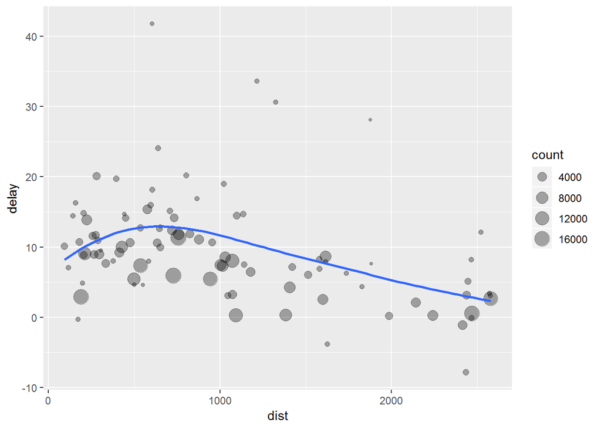

```r
# Create a "delays" data table
delays <- flights %>%
  group_by(dest) %>%
  summarise(
    count = n(),
    dist = mean(distance, na.rm = TRUE),
    delay = mean(arr_delay, na.rm = TRUE)
  ) %>%
  # We don't want any small airports, or Honolulu
  filter(count > 20, dest != "HNL")

# Plot the delays and add a smoother
ggplot(data = delays, mapping = aes(x = dist, y = delay)) +
  geom_point(aes(size = count), alpha = 1/3) +
  geom_smooth(se = FALSE)
```

## 6.2 Adding and Visualising Counts

Let’s look at the average delay by plane. Based on this graph, there are some planes with an *average* delay of over five hours! But how many flights did that plane make? We need to add a count.

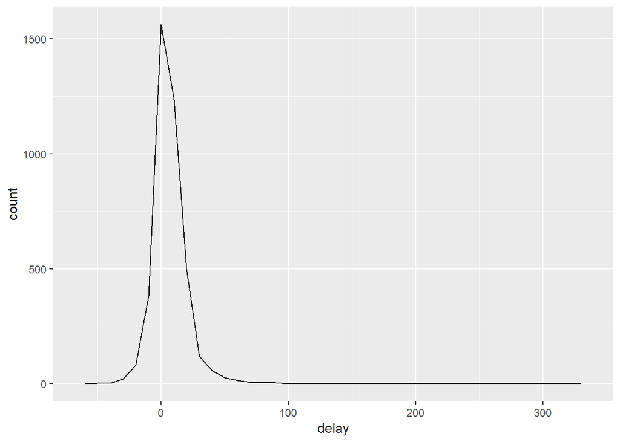

```r
delays <- not_cancelled %>%
  group_by(tail_num) %>%
  summarise(
    delay = mean(arr_delay)
  )

ggplot(data = delays, mapping = aes(x = delay)) +
  geom_freqpoly(binwidth = 10)
```

Now that we add a count and re-plot the average arrival delay, we immediately see the Central Limit Theorem in action. All those planes with massive average delays only had one or two flights.

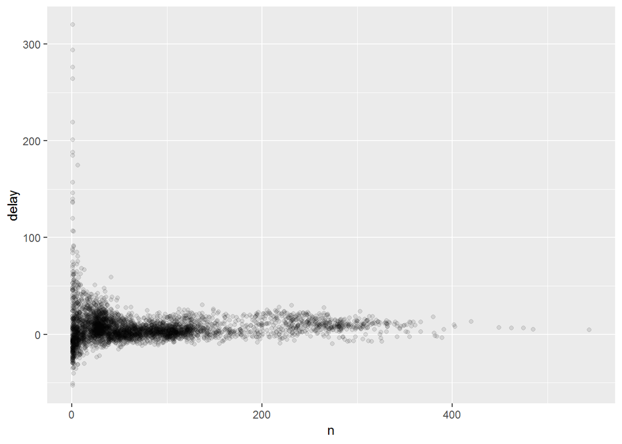

```r
delays <- not_cancelled %>%
  group_by(tail_num) %>%
  summarise(
    delay = mean(arr_delay, na.rm = TRUE),
    n = n()
  )

ggplot(data = delays, mapping = aes(x = n, y = delay)) +
  geom_point(alpha = 1/10)
```

We can remove any planes with fewer than 30 flights and re-visualize the relationships between average delay and number of flights and the overall count-delay distribution.

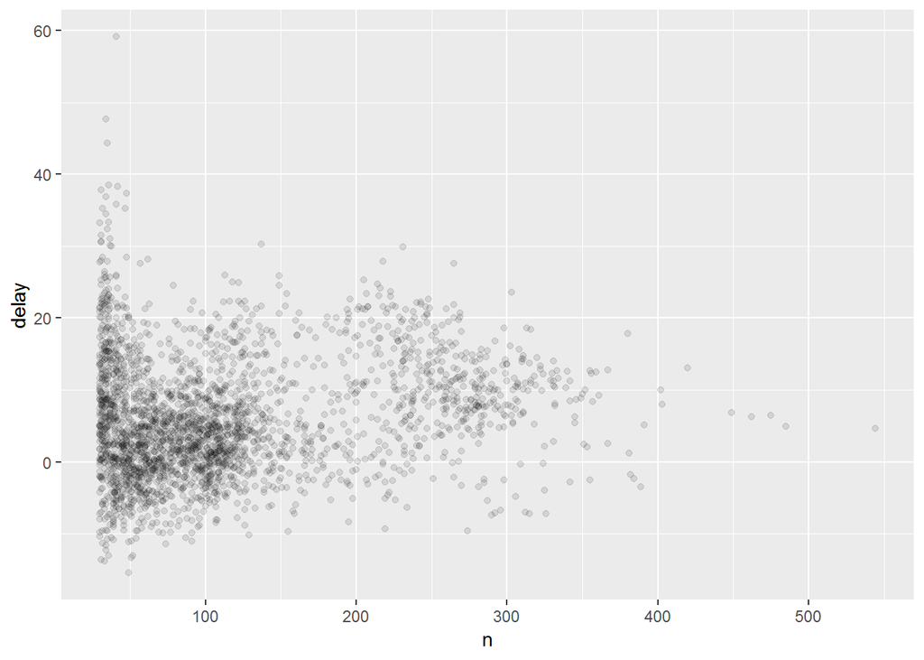

```r
delays %>%
  filter(n >= 30) %>%
  ggplot(mapping = aes(x = n, y = delay)) +
    geom_point(alpha = 1/10)
```

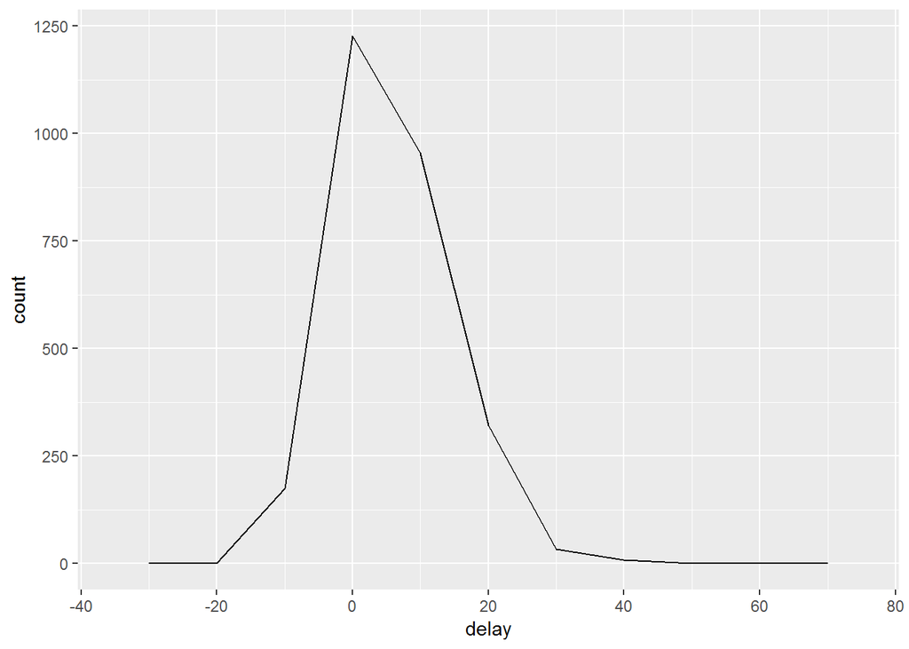

```r
delays %>%
  filter(n >= 30) %>%
  ggplot(mapping = aes(x = delay)) +
  geom_freqpoly(binwidth = 10)
```

## 6.3 Other Useful Summaries

```r
not_cancelled %>%
  group_by(year, month, day) %>%
  summarise(
    avg_delay1 = mean(arr_delay),
    avg_delay2 = mean(arr_delay[arr_delay > 0]) # the average positive delay
  )
```

```
## # A tibble: 365 x 5
## # Groups:   year, month [?]
##     year month   day avg_delay1 avg_delay2
##    <int> <int> <int>      <dbl>      <dbl>
##  1  2013     1     1     12.7         32.5
##  2  2013     1     2     12.7         32.0
##  3  2013     1     3      5.73        27.7
##  4  2013     1     4     -1.93        28.3
##  5  2013     1     5     -1.53        22.6
##  6  2013     1     6      4.24        24.4
##  7  2013     1     7     -4.95        27.8
##  8  2013     1     8     -3.23        20.8
##  9  2013     1     9     -0.264       25.6
## 10  2013     1    10     -5.90        27.3
## # ... with 355 more rows
```

### 6.3.1 Side Note: Logical Subsetting

Recall our “`R` Basics” session: you can subset a vector by using square brackets. Thus, `x[2]` means “show me the second element of `x`”. Let’s see an example; we’ll create a vector of the first 10 integers:

```r
x <- 1:10
x[2]
```

```
## [1] 2
```

We can also subset this vector by a logical (`TRUE`/`FALSE`) vector of the same length.

```r
(logi <- rep(c(TRUE, FALSE), 5))
```

```
##  [1]  TRUE FALSE  TRUE FALSE  TRUE FALSE  TRUE FALSE  TRUE FALSE
```

```r
x[logi]
```

```
## [1] 1 3 5 7 9
```

```r
x > 5
```

```
##  [1] FALSE FALSE FALSE FALSE FALSE  TRUE  TRUE  TRUE  TRUE  TRUE
```

```r
x[x > 5]
```

```
## [1]  6  7  8  9 10
```

Therefore, `mean(vec[vec > 0])` will take the average of all the values in a vector that are positive.

### 6.3.2 Examples

1. We can find the proportion of flights by day that are delayed longer than 1 hour.

```r
not_cancelled %>%
  group_by(year, month, day) %>%
  summarise(hour_perc = mean(arr_delay > 60))
```

```
## # A tibble: 365 x 4
## # Groups:   year, month [?]
##     year month   day hour_perc
##    <int> <int> <int>     <dbl>
##  1  2013     1     1    0.0722
##  2  2013     1     2    0.0851
##  3  2013     1     3    0.0567
##  4  2013     1     4    0.0396
##  5  2013     1     5    0.0349
##  6  2013     1     6    0.0470
##  7  2013     1     7    0.0333
##  8  2013     1     8    0.0213
##  9  2013     1     9    0.0202
## 10  2013     1    10    0.0183
## # ... with 355 more rows
```

2. We can also measure parametric and non-parametric spread or variability.

```r
not_cancelled %>%
  group_by(dest) %>%
  summarise(distance_sd = sd(distance)) %>%
  arrange(desc(distance_sd))
```

```
## # A tibble: 104 x 2
##    dest  distance_sd
##    <chr>       <dbl>
##  1 EGE         10.5
##  2 SAN         10.4
##  3 SFO         10.2
##  4 HNL         10.0
##  5 SEA          9.98
##  6 LAS          9.91
##  7 PDX          9.87
##  8 PHX          9.86
##  9 LAX          9.66
## 10 IND          9.46
## # ... with 94 more rows
```

```r
not_cancelled %>%
  group_by(year, month, day) %>%
  summarise(
    first = min(dep_time),
    p25 = quantile(dep_time, 0.25),
    last = max(dep_time)
  )
```

```
## # A tibble: 365 x 6
## # Groups:   year, month [?]
##     year month   day first   p25  last
##    <int> <int> <int> <dbl> <dbl> <dbl>
##  1  2013     1     1   517  938.  2356
##  2  2013     1     2    42  912.  2354
##  3  2013     1     3    32  909   2349
##  4  2013     1     4    25  901.  2358
##  5  2013     1     5    14  859   2357
##  6  2013     1     6    16 1003   2355
##  7  2013     1     7    49  907.  2359
##  8  2013     1     8   454  858   2351
##  9  2013     1     9     2  858   2252
## 10  2013     1    10     3  859   2320
## # ... with 355 more rows
```

3. Because counting by groups is so common, we can use the shorthand `count()` function.

```r
# Instead of
not_cancelled %>%
  group_by(dest) %>%
  summarise(n = n())
```

```
## # A tibble: 104 x 2
##    dest      n
##    <chr> <int>
##  1 ABQ     254
##  2 ACK     264
##  3 ALB     418
##  4 ANC       8
##  5 ATL   16837
##  6 AUS    2411
##  7 AVL     261
##  8 BDL     412
##  9 BGR     358
## 10 BHM     269
## # ... with 94 more rows
```

```r
# use
not_cancelled %>%
  count(dest)
```

```
## # A tibble: 104 x 2
##    dest      n
##    <chr> <int>
##  1 ABQ     254
##  2 ACK     264
##  3 ALB     418
##  4 ANC       8
##  5 ATL   16837
##  6 AUS    2411
##  7 AVL     261
##  8 BDL     412
##  9 BGR     358
## 10 BHM     269
## # ... with 94 more rows
```

4. The `count()` function can take in weights as well. We can use this to find the planes that logged the most air miles in 2013.

```r
not_cancelled %>%
  count(tail_num, wt = distance) %>%
  arrange(desc(n))
```

```
## # A tibble: 4,037 x 2
##    tail_num      n
##    <chr>     <dbl>
##  1 N328AA   929090
##  2 N338AA   921172
##  3 N335AA   902271
##  4 N327AA   900482
##  5 N323AA   839468
##  6 N319AA   837924
##  7 N336AA   833136
##  8 N329AA   825826
##  9 N324AA   786159
## 10 N339AA   783648
## # ... with 4,027 more rows
```

## 6.4 Grouping by Multiple Variables

We can group on the year, month within year, and day within month. Then, we can “roll up” the data summaries.

```r
daily <- group_by(flights, year, month, day)
per_day <- summarise(daily, flights = n())
per_day
```

```
## # A tibble: 365 x 4
## # Groups:   year, month [?]
##     year month   day flights
##    <int> <int> <int>   <int>
##  1  2013     1     1     842
##  2  2013     1     2     943
##  3  2013     1     3     914
##  4  2013     1     4     915
##  5  2013     1     5     720
##  6  2013     1     6     832
##  7  2013     1     7     933
##  8  2013     1     8     899
##  9  2013     1     9     902
## 10  2013     1    10     932
## # ... with 355 more rows
```

```r
per_month <- summarise(per_day, flights = sum(flights))
per_month
```

```
## # A tibble: 12 x 3
## # Groups:   year [?]
##     year month flights
##    <int> <int>   <int>
##  1  2013     1   27004
##  2  2013     2   24951
##  3  2013     3   28834
##  4  2013     4   28330
##  5  2013     5   28796
##  6  2013     6   28243
##  7  2013     7   29425
##  8  2013     8   29327
##  9  2013     9   27574
## 10  2013    10   28889
## 11  2013    11   27268
## 12  2013    12   28135
```

```r
(per_year  <- summarise(per_month, flights = sum(flights)))
```

```
## # A tibble: 1 x 2
##    year flights
##   <int>   <int>
## 1  2013  336776
```

# 7 Optional: Merge Data Tables with `*_join()`

If you have two or more tables which share one or more columns, then you can join these tables using the `*_join()` family of functions. For two data tables `A` and `B` with a shared column named `"x"`, these functions are

- `left_join(A, B, by = "x")`: join matching rows from `B` to `A`. Missing rows in `B` will be padded with `NA`.
- `right_join(A, B, by = "x")`: join matching rows from `A` to `B`. Missing rows in `A` will be padded with `NA`.
- `inner_join(A, B, by = "x")`: join rows only in both `A` and `B`. There will be no missing rows.
- `full_join(A, B, by = "x")`: join all rows in `A` and `B`. Missing rows in `A` and `B` will be padded with `NA`.
- `semi_join(A, B, by = "x")`: retain rows in `A` which have a match in `B`.
- `anti_join(A, B, by = "x")`: retain rows in `A` which do not have a match in `B`.

# 8 A Comment on Importing Data with `readr`

When you use the RStudio IDE, you have access to a point-and-click data import guide for data files in many different forms. Such forms include tab-seperated, fixed-width, .csv, Stata, SAS, SPSS, Excel, and many others. A word of caution: practice with the `read.fwf()`, `read.table`, and `read.csv` functions from the `base` package in `R`; then, you should practice importing the same data with the `read_fwf()`, `read_delim`, and `read_csv` functions from the `readr` package. Once you are familiar with how the `base` and `readr` functions are different, then you can start using the `readr` functions from a script instead of using the point-and-click RStudio IDE importing steps.

If you have never imported data before, please ask for help. Also, read [this chapter](http://r4ds.had.co.nz/import.html) on importing data from a variety of sources. I have seen many problems in code because a tiny little peice of data was imported incorrectly, and this mistake wormed its way through an entire analysis. Don’t let this happen to you. Ask the [BBSR Core](http://sylvester.org/shared-resources/biostatistics-and-bioinformatics/bbc-administration) for help.